# Covid-19 in Morocco

IGDMW KUMARA

2022-10-07

# **Introduction**

Morocco is a country located in North Africa. It has a coast on the Atlantic Ocean that reaches past the Strait of Gibraltar into the Mediterranean Sea. It is bordered by Spain, Algeria, and Western Sahara. Much of Morocco is mountainous. The Atlas Mountain and Rif Mountains are located on the northern coast and interior. The government system is a parliamentary constitutional monarchy; the chief of state is the king, and the head of government is the prime minister. Morocco is a member of the League of Arab States (Arab League).

## *Location of Morocco*

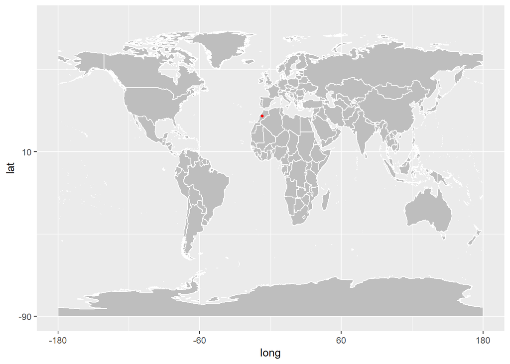

## *Situation of Covid-19 in Morocco*

The COVID-19 pandemic in Morocco is part of the worldwide pandemic of coronavirus disease 2019 (COVID-19) caused by severe acute respiratory syndrome coronavirus 2 (SARS-CoV-2). The virus was confirmed to have spread to Morocco on 2 March 2020, when the first case COVID-19 case was confirmed in Casablanca.[3] It involved a Moroccan expatriate residing in Bergamo, Italy, who arrived from Italy on 27 February. A second case was confirmed later that same day involving an 89-year-old woman Moroccan residing in Italy who had returned to Morocco on 25 February from Bologna, Italy.[4] As the outbreak widened in Morocco, in mid-March the Government closed schools and suspended international passenger flights.

## *Impacts of Covid19 in Morocco*

The COVID-19 pandemic has hit the Moroccan economy hard, as elsewhere in the world. A collapse in external demand and a lockdown lasting more than three months have profoundly altered economic activity in Morocco, causing its first recession since 1995. The implementation of the confinement and social distancing measures was strict and came two weeks after the detection of the first cases of COVID-19 in Morocco on March 2, 2020. The lockdown was extended three times and lasted around 14 weeks. This strategy prevented a sharp increase in cases in the early part of the pandemic, and enabled the preparation of health infrastructure to deal with potentially more severe waves of contamination. However, the price was the consequent economic downturn.

# **Exploratory Data Analysis**

## Visualization of death, confirmed, recovered, active cases

*Confirmed cases in Morocco*

```
      date              province           country               lat
 Min.   :2020-01-22   Length:884         Length:884         Min.   :31.79
 1st Qu.:2020-08-29   Class :character   Class :character   1st Qu.:31.79
 Median :2021-04-07   Mode  :character   Mode  :character   Median :31.79
 Mean   :2021-04-07                                         Mean   :31.79
 3rd Qu.:2021-11-14                                         3rd Qu.:31.79
 Max.   :2022-06-23                                         Max.   :31.79
      long            type               cases            uid
 Min.   :-7.093   Length:884         Min.   :    0   Min.   :504
 1st Qu.:-7.093   Class :character   1st Qu.:  108   1st Qu.:504
 Median :-7.093   Mode  :character   Median :  431   Median :504
 Mean   :-7.093                      Mean   : 1353   Mean   :504
 3rd Qu.:-7.093                      3rd Qu.: 1623   3rd Qu.:504
 Max.   :-7.093                      Max.   :12039   Max.   :504
     iso2               iso3               code3     combined_key
 Length:884         Length:884         Min.   :504   Length:884
 Class :character   Class :character   1st Qu.:504   Class :character
 Mode  :character   Mode  :character   Median :504   Mode  :character
                                       Mean   :504
                                       3rd Qu.:504
                                       Max.   :504
   population       continent_name     continent_code
 Min.   :36910558   Length:884         Length:884
 1st Qu.:36910558   Class :character   Class :character
 Median :36910558   Mode  :character   Mode  :character
 Mean   :36910558
 3rd Qu.:36910558
 Max.   :36910558
```

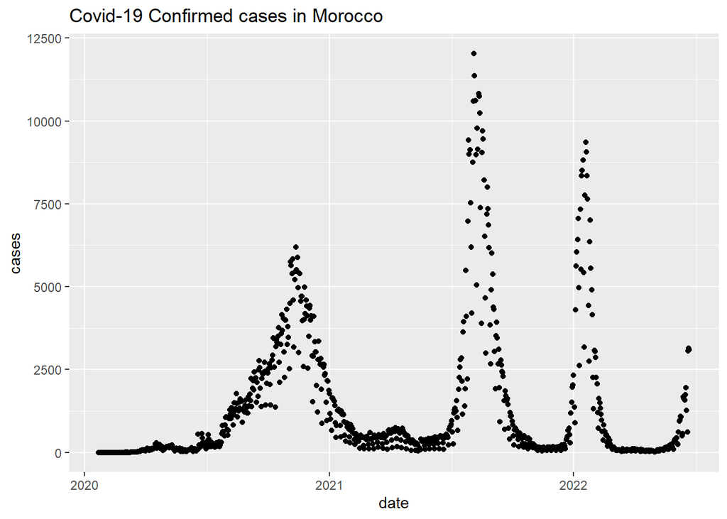

*Deaths in Morocco*

```
      date              province           country               lat
 Min.   :2020-01-22   Length:884         Length:884         Min.   :31.79
 1st Qu.:2020-08-29   Class :character   Class :character   1st Qu.:31.79
 Median :2021-04-07   Mode  :character   Mode  :character   Median :31.79
 Mean   :2021-04-07                                         Mean   :31.79
 3rd Qu.:2021-11-14                                         3rd Qu.:31.79
 Max.   :2022-06-23                                         Max.   :31.79
      long            type               cases             uid
 Min.   :-7.093   Length:884         Min.   :  0.00   Min.   :504
 1st Qu.:-7.093   Class :character   1st Qu.:  1.00   1st Qu.:504
 Median :-7.093   Mode  :character   Median :  6.00   Median :504
 Mean   :-7.093                      Mean   : 18.21   Mean   :504
 3rd Qu.:-7.093                      3rd Qu.: 28.25   3rd Qu.:504
 Max.   :-7.093                      Max.   :127.00   Max.   :504
     iso2               iso3               code3     combined_key
 Length:884         Length:884         Min.   :504   Length:884
 Class :character   Class :character   1st Qu.:504   Class :character
 Mode  :character   Mode  :character   Median :504   Mode  :character
                                       Mean   :504
                                       3rd Qu.:504
                                       Max.   :504
   population       continent_name     continent_code
 Min.   :36910558   Length:884         Length:884
 1st Qu.:36910558   Class :character   Class :character
 Median :36910558   Mode  :character   Mode  :character
 Mean   :36910558
 3rd Qu.:36910558
 Max.   :36910558
```

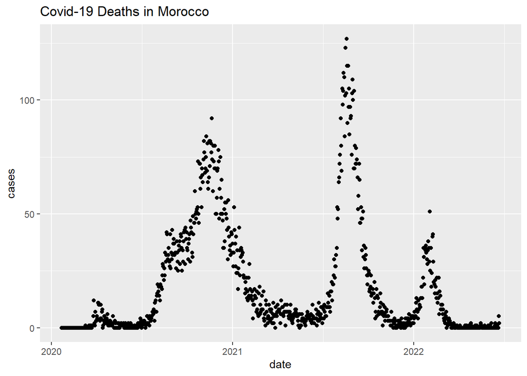

*Recovered cases in Morocco*

```
      date              province           country               lat
 Min.   :2020-01-22   Length:884         Length:884         Min.   :31.79
 1st Qu.:2020-08-29   Class :character   Class :character   1st Qu.:31.79
 Median :2021-04-07   Mode  :character   Mode  :character   Median :31.79
 Mean   :2021-04-07                                         Mean   :31.79
 3rd Qu.:2021-11-14                                         3rd Qu.:31.79
 Max.   :2022-06-23                                         Max.   :31.79
      long            type               cases               uid
 Min.   :-7.093   Length:884         Min.   :     0.0   Min.   :504
 1st Qu.:-7.093   Class :character   1st Qu.:     0.0   1st Qu.:504
 Median :-7.093   Mode  :character   Median :    74.5   Median :504
 Mean   :-7.093                      Mean   :  1318.3   Mean   :504
 3rd Qu.:-7.093                      3rd Qu.:   678.0   3rd Qu.:504
 Max.   :-7.093                      Max.   :582692.0   Max.   :504
     iso2               iso3               code3     combined_key
 Length:884         Length:884         Min.   :504   Length:884
 Class :character   Class :character   1st Qu.:504   Class :character
 Mode  :character   Mode  :character   Median :504   Mode  :character
                                       Mean   :504
                                       3rd Qu.:504
                                       Max.   :504
   population       continent_name     continent_code
 Min.   :36910558   Length:884         Length:884
 1st Qu.:36910558   Class :character   Class :character
 Median :36910558   Mode  :character   Mode  :character
 Mean   :36910558
 3rd Qu.:36910558
 Max.   :36910558
```

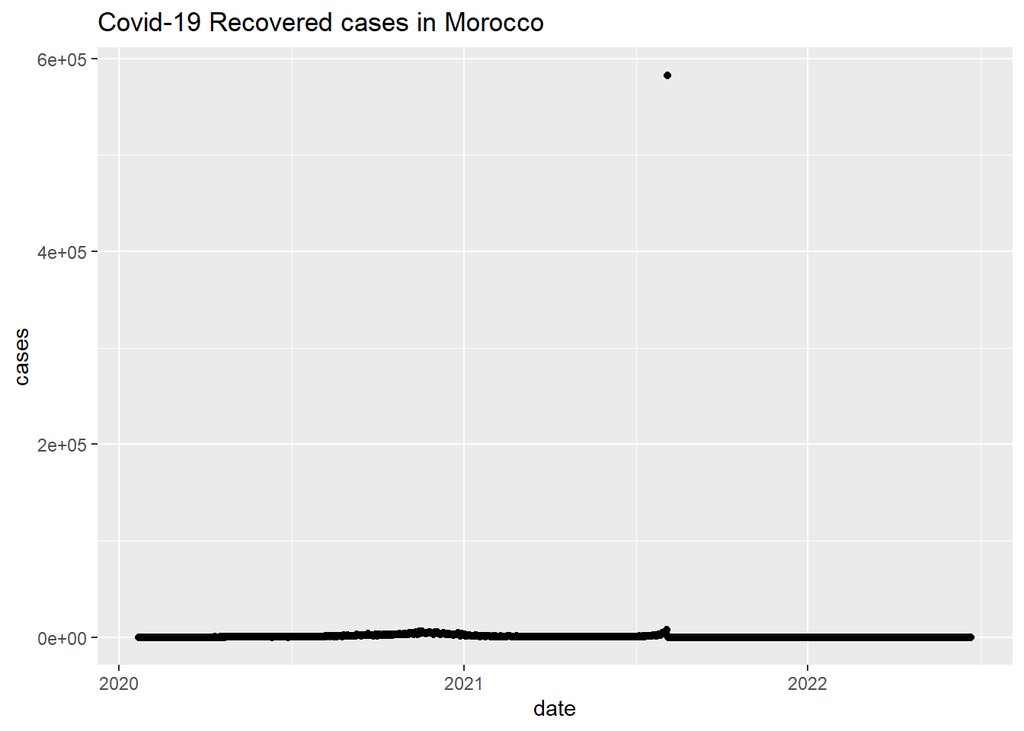

*Active cases in Morocco*

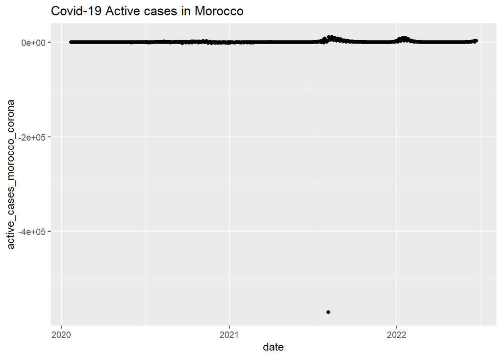

*Covid-19 cases in Morocco by type*

[figure not shown]

## Comparison with other countries

[output not shown]

[output cut: 85 more lines]

*Comparison of deaths between Morocco, Spain and Algeria*

```
      date              province           country               lat
 Min.   :2020-01-22   Length:7956        Length:7956        Min.   :28.03
 1st Qu.:2020-08-29   Class :character   Class :character   1st Qu.:28.03
 Median :2021-04-07   Mode  :character   Mode  :character   Median :31.79
 Mean   :2021-04-07                                         Mean   :33.43
 3rd Qu.:2021-11-14                                         3rd Qu.:40.46
 Max.   :2022-06-23                                         Max.   :40.46
      long            type               cases             uid
 Min.   :-7.093   Length:7956        Min.   :     0   Min.   : 12.0
 1st Qu.:-7.093   Class :character   1st Qu.:     0   1st Qu.: 12.0
 Median :-3.749   Mode  :character   Median :    18   Median :504.0
 Mean   :-3.061                      Mean   :  2022   Mean   :413.3
 3rd Qu.: 1.660                      3rd Qu.:   305   3rd Qu.:724.0
 Max.   : 1.660                      Max.   :582692   Max.   :724.0
     iso2               iso3               code3       combined_key
 Length:7956        Length:7956        Min.   : 12.0   Length:7956
 Class :character   Class :character   1st Qu.: 12.0   Class :character
 Mode  :character   Mode  :character   Median :504.0   Mode  :character
                                       Mean   :413.3
                                       3rd Qu.:724.0
                                       Max.   :724.0
   population       continent_name     continent_code
 Min.   :36910558   Length:7956        Length:7956
 1st Qu.:36910558   Class :character   Class :character
 Median :43851043   Mode  :character   Mode  :character
 Mean   :42505461
 3rd Qu.:46754783
 Max.   :46754783
```

```
      date              province           country               lat
 Min.   :2020-01-22   Length:2652        Length:2652        Min.   :28.03
 1st Qu.:2020-08-29   Class :character   Class :character   1st Qu.:28.03
 Median :2021-04-07   Mode  :character   Mode  :character   Median :31.79
 Mean   :2021-04-07                                         Mean   :33.43
 3rd Qu.:2021-11-14                                         3rd Qu.:40.46
 Max.   :2022-06-23                                         Max.   :40.46
      long            type               cases              uid
 Min.   :-7.093   Length:2652        Min.   :   0.00   Min.   : 12.0
 1st Qu.:-7.093   Class :character   1st Qu.:   1.00   1st Qu.: 12.0
 Median :-3.749   Mode  :character   Median :   7.00   Median :504.0
 Mean   :-3.061                      Mean   :  50.82   Mean   :413.3
 3rd Qu.: 1.660                      3rd Qu.:  31.00   3rd Qu.:724.0
 Max.   : 1.660                      Max.   :1918.00   Max.   :724.0
     iso2               iso3               code3       combined_key
 Length:2652        Length:2652        Min.   : 12.0   Length:2652
 Class :character   Class :character   1st Qu.: 12.0   Class :character
 Mode  :character   Mode  :character   Median :504.0   Mode  :character
                                       Mean   :413.3
                                       3rd Qu.:724.0
                                       Max.   :724.0
   population       continent_name     continent_code
 Min.   :36910558   Length:2652        Length:2652
 1st Qu.:36910558   Class :character   Class :character
 Median :43851043   Mode  :character   Mode  :character
 Mean   :42505461
 3rd Qu.:46754783
 Max.   :46754783
```

[figure not shown]

*Comparison of confirmed cases between Morocco, Spain and Algeria*

```
      date              province           country               lat
 Min.   :2020-01-22   Length:7956        Length:7956        Min.   :28.03
 1st Qu.:2020-08-29   Class :character   Class :character   1st Qu.:28.03
 Median :2021-04-07   Mode  :character   Mode  :character   Median :31.79
 Mean   :2021-04-07                                         Mean   :33.43
 3rd Qu.:2021-11-14                                         3rd Qu.:40.46
 Max.   :2022-06-23                                         Max.   :40.46
      long            type               cases             uid
 Min.   :-7.093   Length:7956        Min.   :     0   Min.   : 12.0
 1st Qu.:-7.093   Class :character   1st Qu.:     0   1st Qu.: 12.0
 Median :-3.749   Mode  :character   Median :    18   Median :504.0
 Mean   :-3.061                      Mean   :  2022   Mean   :413.3
 3rd Qu.: 1.660                      3rd Qu.:   305   3rd Qu.:724.0
 Max.   : 1.660                      Max.   :582692   Max.   :724.0
     iso2               iso3               code3       combined_key
 Length:7956        Length:7956        Min.   : 12.0   Length:7956
 Class :character   Class :character   1st Qu.: 12.0   Class :character
 Mode  :character   Mode  :character   Median :504.0   Mode  :character
                                       Mean   :413.3
                                       3rd Qu.:724.0
                                       Max.   :724.0
   population       continent_name     continent_code
 Min.   :36910558   Length:7956        Length:7956
 1st Qu.:36910558   Class :character   Class :character
 Median :43851043   Mode  :character   Mode  :character
 Mean   :42505461
 3rd Qu.:46754783
 Max.   :46754783
```

```
      date              province           country               lat
 Min.   :2020-01-22   Length:2652        Length:2652        Min.   :28.03
 1st Qu.:2020-08-29   Class :character   Class :character   1st Qu.:28.03
 Median :2021-04-07   Mode  :character   Mode  :character   Median :31.79
 Mean   :2021-04-07                                         Mean   :33.43
 3rd Qu.:2021-11-14                                         3rd Qu.:40.46
 Max.   :2022-06-23                                         Max.   :40.46
      long            type               cases             uid
 Min.   :-7.093   Length:2652        Min.   :     0   Min.   : 12.0
 1st Qu.:-7.093   Class :character   1st Qu.:    74   1st Qu.: 12.0
 Median :-3.749   Mode  :character   Median :   314   Median :504.0
 Mean   :-3.061                      Mean   :  5372   Mean   :413.3
 3rd Qu.: 1.660                      3rd Qu.:  2144   3rd Qu.:724.0
 Max.   : 1.660                      Max.   :372766   Max.   :724.0
     iso2               iso3               code3       combined_key
 Length:2652        Length:2652        Min.   : 12.0   Length:2652
 Class :character   Class :character   1st Qu.: 12.0   Class :character
 Mode  :character   Mode  :character   Median :504.0   Mode  :character
                                       Mean   :413.3
                                       3rd Qu.:724.0
                                       Max.   :724.0
   population       continent_name     continent_code
 Min.   :36910558   Length:2652        Length:2652
 1st Qu.:36910558   Class :character   Class :character
 Median :43851043   Mode  :character   Mode  :character
 Mean   :42505461
 3rd Qu.:46754783
 Max.   :46754783
```